# **NOTE:** Use File > Save a copy in Drive to make a copy before doing anything else

# Project 7: Data Exploration and Visualization

### Overview

In this project, you will apply data exploration and visualization techniques to a real-world dataset of your choice. You'll practice using pandas for data analysis and create meaningful visualizations to gain insights from your data. This project builds on your Python programming skills while introducing you to the exciting world of data science.

In [Lab7](https://colab.research.google.com/drive/15QvSh0csZaCU-OuuPIfpWx5wLDDjmqK4?usp=sharing), you explore the titanic dataset and you should use it as a sample and pick a dataset of your interest to do a similar data exploration and visualization.

### Project Objectives

- Find and select a dataset from a real-world data source
- Formulate a clear inquiry question based on your chosen dataset
- Perform exploratory data analysis using pandas functions
- Create at least two meaningful data visualizations
- Analyze your findings and answer your inquiry question
- Reflect on the insights gained through data exploration

### Data Sources

You can choose from various online data sources such as:

- [Kaggle](https://www.kaggle.com/datasets) - Wide variety of datasets
- [data.gov](https://www.data.gov/) - U.S. government data
- [Our World in Data](https://ourworldindata.org/) - Global development data
- [GitHub](https://github.com/datasets) - Curated datasets
- [Google Dataset Search](https://datasetsearch.research.google.com/) - Search for datasets
- Or any other reliable data source you find interesting

## Part 1: Dataset Selection and Initial Exploration

#### TODO Tasks:

1. Select Your Dataset: Choose a dataset that interests you. Make sure it has at least 100 rows and multiple columns with different data types (e.g., numerical, categorical, dates).

Please create either text or code cells in between the TODO tasks to do the work.

2. Import Libraries: Import the necessary libraries (pandas, matplotlib, seaborn) at the beginning of your notebook by creating code cells below this text cell.

```python
!pip install pandas==2.2.2
!pip install seaborn==0.13.2
```

3. Load Your Data: Load your chosen dataset using pandas and save it to a pandas dataframe. Please create a code cell below this text cell to do it.

```python
import pandas as pd

URL = "https://raw.githubusercontent.com/Mhenn726/California_Wildfires/refs/heads/main/top_20_CA_wildfires.csv"
df = pd.read_csv(URL)
```

4. Data Summary: Use the following functions to do inital exploration your dataset:
- info() - Display information about the dataset structure
- describe() - Show statistical summary of numerical columns
- head() - Display the first 5 rows (df.head())
- shape - Show the dimensions of the dataset (e.g. df.shape)
- columns - Get the column names (e.g. df.columns)

You may use 5 code cells below this text cell to accomplish it.

```python
df.info()
```

```
<class 'pandas.core.frame.DataFrame'>
RangeIndex: 20 entries, 0 to 19
Data columns (total 8 columns):
 #   Column      Non-Null Count  Dtype
---  ------      --------------  -----
 0   fire_name   20 non-null     object
 1   cause       20 non-null     object
 2   month       20 non-null     object
 3   year        20 non-null     int64
 4   county      20 non-null     object
 5   acres       20 non-null     int64
 6   structures  20 non-null     int64
 7   deaths      20 non-null     int64
dtypes: int64(4), object(4)
memory usage: 1.4+ KB
```

```python
df.describe()
```

|  | year | acres | structures | deaths |
| --- | --- | --- | --- | --- |
| count | 20.000000 | 20.000000 | 20.00000 | 20.000000 |
| mean | 2001.300000 | 210266.200000 | 1352.65000 | 6.150000 |
| std | 20.956346 | 75150.676664 | 4178.21521 | 18.918871 |
| min | 1932.000000 | 140948.000000 | 0.00000 | 0.000000 |
| 25% | 2001.250000 | 158751.750000 | 0.75000 | 0.000000 |
| 50% | 2007.500000 | 184952.000000 | 43.00000 | 0.500000 |
| 75% | 2013.500000 | 244483.750000 | 552.25000 | 2.000000 |
| max | 2018.000000 | 459123.000000 | 18804.00000 | 85.000000 |

```python
df.head()
```

|  | fire_name | cause | month | year | county | acres | structures | deaths |
| --- | --- | --- | --- | --- | --- | --- | --- | --- |
| 0 | Mendocino Complex | Under Investigation | July | 2018 | Colusa County, Lake County, Mendocino County &... | 459123 | 280 | 1 |
| 1 | Thomas | Powerlines | December | 2017 | Ventura & Santa Barbara | 281893 | 1063 | 2 |
| 2 | Cedar | Human Related | October | 2003 | San Diego | 273246 | 2820 | 15 |
| 3 | Rush | Lightning | August | 2012 | Lassen | 271911 | 0 | 0 |
| 4 | Rim | Human Related | August | 2013 | Tuolumne | 257314 | 112 | 0 |

```python
df.shape
```

```
(20, 8)
```

```python
df.columns
```

```
Index(['fire_name', 'cause', 'month', 'year', 'county', 'acres', 'structures',
       'deaths'],
      dtype='object')
```

5. Inquiry Question: Write a clear, specific question that you want to answer using your dataset by creating a text cell below and **write the question in bold please.**

For example:

- "How has the average temperature changed in major cities over the past decade?"
- "What factors are most strongly correlated with housing prices?"
- "Is there a relationship between education level and income?"

**Is there a relationship between the month and cause of the fires?**

## Part 2: Data Visualization and Analysis

#### TODO Tasks:

1. Data Cleaning (if necessary): Check for and handle any missing values, duplicates, or data quality issues.

**NOTE: This could be a daunting task even for seasoned data scientists. My suggestion is to use a dataset that is already clean if you can for the purpose of completing this assignment in a week.**

Examples:

- Checking for missing values: df.isnull().sum()
- Dropping rows with any missing values: df.dropna(inplace=True)
- Dropping columns with all missing values: df.dropna(axis=1, how='all', inplace=True)
- Removing duplicate row: df.drop_duplicates(inplace=True)

```python
df.isnull().sum()
```

|  | 0 |
| --- | --- |
| fire_name | 0 |
| cause | 0 |
| month | 0 |
| year | 0 |
| county | 0 |
| acres | 0 |
| structures | 0 |
| deaths | 0 |

**dtype:** int64

2. Create Visualizations: Create at least 2 different types of visualizations that help answer your research question. Choose from:
- Bar charts
- Line plots
- Scatter plots
- Histograms
- Box plots
- Heatmaps
- Any other appropriate visualization
3. Customize Your Plots: Make sure your visualizations are clear and informative by:
- Adding appropriate titles
- Labeling axes
- Using colors effectively
- Adding legends when necessary

Please create code cells below this to create your visualizations.

```python
from matplotlib import pyplot as plt
import seaborn as sns
sns.set_theme(style="darkgrid")
```

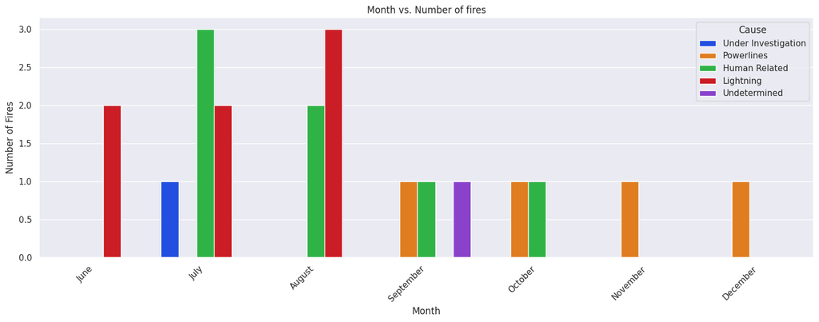

```python
import pandas as pd
import matplotlib.pyplot as plt

month_order = ['June','July', 'August', 'September', 'October', 'November', 'December']
df['month'] = pd.Categorical(df['month'], categories=month_order, ordered=True)

plt.figure(figsize=(15, 6))
sns.countplot(data=df, x='month', hue='cause', palette='bright')
plt.title('Month vs. Number of fires')
plt.xlabel('Month')
plt.ylabel('Number of Fires')
plt.xticks(rotation=45, ha='right')
plt.legend(title='Cause')
plt.tight_layout()
plt.show()
```

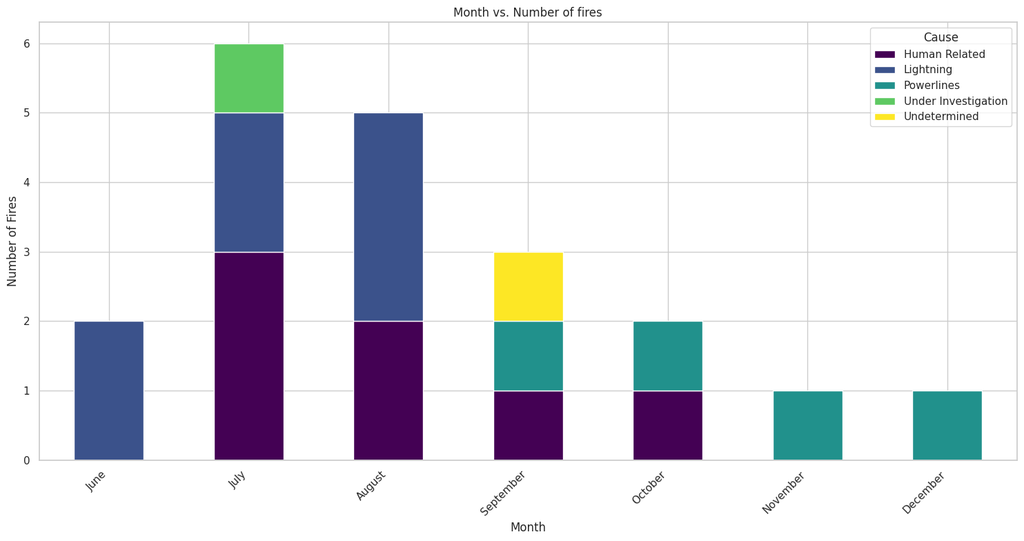

```python
import matplotlib.pyplot as plt
cause_by_month = df.groupby(['month', 'cause']).size().unstack(fill_value=0)

plt.figure(figsize=(15, 8))
cause_by_month.plot(kind='bar', stacked=True, figsize=(15, 8), colormap='viridis')

plt.title('Month vs. Number of fires')
plt.xlabel('Month')
plt.ylabel('Number of Fires')
plt.xticks(rotation=45, ha='right')
plt.legend(title='Cause')
plt.tight_layout()
plt.show()
```

4. Analysis: Write 1-2 paragraphs discussing:
- Whether your research question can be answered with the available data
- What insights you discovered through your visualizations
- Any unexpected or interesting findings
- Limitations of your analysis
- Suggestions for further investigation

Please create a text cell below this cell to write your analysis.

My original research question asked "Is there a relationship between the month and cause of the fires?" After creating two visualizations, I can confirm that there are more fires in the months of July and August. In both charts, we can see that lightning and human related activities are the major causes of fires in these specific months. While making my visualization maps, I discovered that powerline failures are the biggest cause of fires from september through december.

Unfortunately, because my chart did not have a lot of data, I found it difficult to create bigger, and more complex charts like a scatterplot or a line plot. The data that I chose to analyze only had 20 unique data values, which created major limitations on what I could add to my charts. The benefits, on the other hand, make it very easy to read and clean up. If I chose to analyze datasets again, I will find one that offers more data.

```python
from google.colab import drive
drive.mount('/content/drive')
```

## NOTE: If you use a local dataset, you MUST submit the dataset along with your notebook to get credit.

- Download your notebook as CS110_Project7.ipynb
- Ensure all TODO tasks are completed
- Make sure your code runs without errors
- Include clear comments explaining your work
- Submit the notebook file

## Grading Criteria (4 points)

- Dataset Selection: Appropriate choice of dataset with sufficient complexity
- Inquiry Question: Clear, specific, and answerable with the chosen data
- Data Exploration: Proper use of pandas functions for initial analysis
- Visualizations: At least 2 clear, well-formatted, and relevant plots
- Analysis: Thoughtful interpretation of findings and answer to research question
- Code Quality: Clean, commented, and well-organized code

Remember: The goal is not just to create visualizations, but to use them to gain meaningful insights about your data. Think like a data scientist and let your curiosity guide your exploration!